# Regresi Peubah Lag

M.Taqy Abiyu Dzakwan

2025-09-14

```r
knitr::opts_chunk$set(
  warning = FALSE,  # sembunyikan warning
  message = FALSE   # sembunyikan message
)
```

# Panggil Library

```r
library(dLagM)
library(dynlm)
library(MLmetrics)
library(lmtest)
library(readr)
library(dplyr)
```

# Import Data

Data yang digunakan berasal dari air quality New Delhi dengan peubah Y yaitu AQI (Air Quality Index) dan peubah X yaitu PM 2,5

```r
dt <- read_csv("D:\\TUGAS IPB\\Semester 5\\mpdw\\Pertemuan 4\\NewDelhi_Air_quality.csv")
str(dt)
```

```
## spc_tbl_ [72 × 12] (S3: spec_tbl_df/tbl_df/tbl/data.frame)
##  $ ...1           : num [1:72] 0 1 2 3 4 5 6 7 8 9 ...
##  $ AQI            : num [1:72] 30.2 28.2 26.6 25 26 26 26 24 23 24 ...
##  $ CO             : num [1:72] 199 198 199 202 205 ...
##  $ datetime       : chr [1:72] "2022-10-21:18" "2022-10-21:19" "2022-10-21:20" "2022-10-21:21" ...
##  $ no2            : num [1:72] 0.0469 0.0465 0.0469 0.0482 0.0489 ...
##  $ o3             : num [1:72] 55.8 54.9 54.6 55.1 55.8 ...
##  $ pm10           : num [1:72] 10.5 10.7 11.2 11.1 10.4 ...
##  $ pm25           : num [1:72] 5.64 4.62 3.52 2.23 1.98 ...
##  $ so2            : num [1:72] 0.387 0.41 0.402 0.376 0.339 ...
##  $ timestamp_local: POSIXct[1:72], format: "2022-10-21 23:00:00" "2022-10-22 00:00:00" ...
##  $ timestamp_utc  : POSIXct[1:72], format: "2022-10-21 18:00:00" "2022-10-21 19:00:00" ...
##  $ ts             : num [1:72] 1.67e+09 1.67e+09 1.67e+09 1.67e+09 1.67e+09 ...
##  - attr(*, "spec")=
##   .. cols(
##   ..   ...1 = col_double(),
##   ..   AQI = col_double(),
##   ..   CO = col_double(),
##   ..   datetime = col_character(),
##   ..   no2 = col_double(),
##   ..   o3 = col_double(),
##   ..   pm10 = col_double(),
##   ..   pm25 = col_double(),
##   ..   so2 = col_double(),
##   ..   timestamp_local = col_datetime(format = ""),
##   ..   timestamp_utc = col_datetime(format = ""),
##   ..   ts = col_double()
##   .. )
##  - attr(*, "problems")=<externalptr>
```

```r
head(dt)
```

```
## # A tibble: 6 × 12
##    ...1   AQI    CO datetime     no2    o3  pm10  pm25   so2 timestamp_local
##   <dbl> <dbl> <dbl> <chr>      <dbl> <dbl> <dbl> <dbl> <dbl> <dttm>
## 1     0  30.2  199. 2022-10-… 0.0469  55.8 10.5   5.64 0.387 2022-10-21 23:00:00
## 2     1  28.2  198. 2022-10-… 0.0465  54.9 10.7   4.62 0.410 2022-10-22 00:00:00
## 3     2  26.6  199. 2022-10-… 0.0469  54.6 11.2   3.52 0.402 2022-10-22 01:00:00
## 4     3  25    202. 2022-10-… 0.0482  55.1 11.1   2.23 0.376 2022-10-22 02:00:00
## 5     4  26    205. 2022-10-… 0.0489  55.8 10.4   1.98 0.339 2022-10-22 03:00:00
## 6     5  26    209. 2022-10-… 0.0502  56.5  9.40  1.79 0.313 2022-10-22 04:00:00
## # ℹ 2 more variables: timestamp_utc <dttm>, ts <dbl>
```

# Splitting Data

```r
data <- dt %>%
  rename(
    Yt = AQI,
    Xt = pm25
  )

head(data)
```

```
## # A tibble: 6 × 12
##    ...1    Yt    CO datetime     no2    o3  pm10    Xt   so2 timestamp_local
##   <dbl> <dbl> <dbl> <chr>      <dbl> <dbl> <dbl> <dbl> <dbl> <dttm>
## 1     0  30.2  199. 2022-10-… 0.0469  55.8 10.5   5.64 0.387 2022-10-21 23:00:00
## 2     1  28.2  198. 2022-10-… 0.0465  54.9 10.7   4.62 0.410 2022-10-22 00:00:00
## 3     2  26.6  199. 2022-10-… 0.0469  54.6 11.2   3.52 0.402 2022-10-22 01:00:00
## 4     3  25    202. 2022-10-… 0.0482  55.1 11.1   2.23 0.376 2022-10-22 02:00:00
## 5     4  26    205. 2022-10-… 0.0489  55.8 10.4   1.98 0.339 2022-10-22 03:00:00
## 6     5  26    209. 2022-10-… 0.0502  56.5  9.40  1.79 0.313 2022-10-22 04:00:00
## # ℹ 2 more variables: timestamp_utc <dttm>, ts <dbl>
```

```r
train<-data[0:57,]
test<-data[58:71,]
train.ts<-ts(train)
test.ts<-ts(test)
data.ts<-ts(data)
```

# Model Koyck

## Pemodelan

```r
model.koyck <- koyckDlm(x = train$Xt, y = train$Yt)
summary(model.koyck)
```

```
##
## Call:
## "Y ~ (Intercept) + Y.1 + X.t"
##
## Residuals:
##      Min       1Q   Median       3Q      Max
## -2.19768 -0.57669 -0.03615  0.58158  2.18318
##
## Coefficients:
##             Estimate Std. Error t value Pr(>|t|)
## (Intercept)  4.54910    1.77579   2.562   0.0133 *
## Y.1          0.87326    0.05731  15.237   <2e-16 ***
## X.t         -0.56825    0.27658  -2.055   0.0449 *
## ---
## Signif. codes:  0 '***' 0.001 '**' 0.01 '*' 0.05 '.' 0.1 ' ' 1
##
## Residual standard error: 0.8986 on 53 degrees of freedom
## Multiple R-Squared: 0.8303,  Adjusted R-squared: 0.8239
## Wald test: 129.9 on 2 and 53 DF,  p-value: < 2.2e-16
##
## Diagnostic tests:
## NULL
##
##                             alpha       beta      phi
## Geometric coefficients:  35.89204 -0.5682546 0.873256
```

```r
AIC(model.koyck)
```

```
## [1] 151.8615
```

```r
BIC(model.koyck)
```

```
## [1] 159.9629
```

Berdasarkan hasil analisis regresi, diperoleh bahwa peubah $Y_{t-1}$ memiliki nilai p-value < 2e-16, sedangkan peubah $X_t$ memiliki nilai p-value 0.0449. Kedua nilai p-value tersebut lebih kecil dari taraf signifikansi α=0.05. Hal ini menunjukkan bahwa peubah $Y_{t-1}$ maupun peubah $X_t$ *berpengaruh secara signifikan* terhadap $Y_t$ pada taraf 5%.

Adapun model regresi yang terbentuk dapat dituliskan sebagai berikut:

$$\hat{Y_t}=4,54910-0.56825X_t+ 0.87326Y_{t-1}$$

Dengan demikian, dapat disimpulkan bahwa perubahan nilai $Y_t$ dipengaruhi secara signifikan oleh dua faktor. Faktor utama adalah nilai $Y_t$ pada periode sebelumnya ($Y_{t-1}$), yang memiliki pengaruh positif sangat kuat. Selain itu, nilai $X_t$ juga memberikan pengaruh yang signifikan namun dengan arah yang negatif. Artinya, kenaikan nilai $X_t$ justru akan menurunkan nilai $Y_t$, dengan asumsi variabel lain konstan.

## Peramalan

Berikut adalah hasil peramalan y untuk 14 periode kedepan menggunakan model koyck

```r
# Forecast dengan model Koyck
fore.koyck <- forecast(model = model.koyck, x=test$Xt, h=14)
fore.koyck
```

```
## $forecasts
##  [1] 24.95927 24.78189 24.49412 24.19650 23.90670 23.66965 23.52745 23.47683
##  [9] 23.47525 23.49718 23.52224 23.54830 23.55405 23.53805
##
## $call
## forecast.koyckDlm(model = model.koyck, x = test$Xt, h = 14)
##
## attr(,"class")
## [1] "forecast.koyckDlm" "dLagM"
```

```r
# Hitung MAPE untuk data test
mape.koyck <- MAPE(fore.koyck$forecasts, test$Yt)
mape.koyck
```

```
## [1] 0.138091
```

```r
# Akurasi data training (Goodness of Fit)
GoF(model.koyck)
```

```
##              n       MAE         MPE       MAPE      sMAPE     MASE       MSE
## model.koyck 56 0.6708393 -0.00101664 0.02495405 0.02490925 1.048186 0.7642032
##                  MRAE   GMRAE
## model.koyck 836328982 13944.2
```

Hasil menunjukkan bahwa nilai *MAPE* (Mean Absolute Percentage Error) pada model Koyck tergolong *sangat baik*, yakni sebesar *2.495%*.

# Regression with Distributed Lag

Regresi dengan atribut lag memerlukan suatu parameter q yang disesuaikan dengan banyaknya dan kondisi data. Agar hasil model maksimal, maka dapat ditentukan terlebih dahulu nilai q atau lag yang optimum.

## *Lag* Optimum

```r
finiteDLMauto(formula = Yt ~ Xt,
              data = data.frame(train), q.min = 1, q.max = 30,
              model.type = "dlm", error.type = "AIC", trace = FALSE)
```

```
##    q - k MASE  AIC  BIC GMRAE   MBRAE R.Adj.Sq Ljung-Box
## 28    28    0 -Inf -Inf     0 0.23214      NaN       NaN
```

Berdasarkan output tersebut, lag optimum didapatkan ketika lag=27 (karena 28 sudah infinite). Selanjutnya dilakukan pemodelan untuk lag=27.

### Pakai AIC BIC

```r
model.dlm <- dlm(x = train$Xt,y = train$Yt , q = 27)
summary(model.dlm)
```

```
##
## Call:
## lm(formula = model.formula, data = design)
##
## Residuals:
##          1          2          3          4          5          6          7
## -0.0019089  0.0027346 -0.0034411 -0.0014318  0.0045122 -0.0069610  0.0108759
##          8          9         10         11         12         13         14
## -0.0171263  0.0120124  0.0101444 -0.0199861  0.0326809 -0.0322894 -0.0007379
##         15         16         17         18         19         20         21
##  0.0070889  0.0223903 -0.0470671  0.0304543  0.0176910 -0.0305087  0.0197407
##         22         23         24         25         26         27         28
## -0.0153639  0.0299397 -0.0491427  0.0257677  0.0170993 -0.0408345  0.0351449
##         29         30
## -0.0248571  0.0133794
##
## Coefficients:
##             Estimate Std. Error t value Pr(>|t|)
## (Intercept)  55.3132    23.3793   2.366    0.255
## x.t         -20.9551     5.4016  -3.879    0.161
## x.1          19.4559     6.0265   3.228    0.191
## x.2         -23.5544    12.1285  -1.942    0.303
## x.3          24.5065    15.7624   1.555    0.364
## x.4         -13.9293    14.3116  -0.973    0.509
## x.5          -3.4143     9.7974  -0.348    0.787
## x.6          13.3343     9.6048   1.388    0.397
## x.7          -1.4064     8.6417  -0.163    0.897
## x.8          -7.6927     8.7358  -0.881    0.540
## x.9           2.3540    10.3064   0.228    0.857
## x.10         22.2707    15.1215   1.473    0.380
## x.11        -20.5220    12.4707  -1.646    0.348
## x.12         -1.7492     6.9637  -0.251    0.843
## x.13          4.2970     9.7403   0.441    0.736
## x.14          0.7338     9.3064   0.079    0.950
## x.15         -0.5496     9.0597  -0.061    0.961
## x.16        -34.3390     9.1975  -3.734    0.167
## x.17         54.3612    14.2365   3.818    0.163
## x.18        -40.7019    10.5892  -3.844    0.162
## x.19         25.0111     9.4104   2.658    0.229
## x.20         -8.1499     8.3830  -0.972    0.509
## x.21         -6.8374     4.7536  -1.438    0.387
## x.22         11.1115     4.0319   2.756    0.222
## x.23         -8.7804     2.8366  -3.095    0.199
## x.24          1.8236     2.9401   0.620    0.647
## x.25          3.0897     1.3053   2.367    0.254
## x.26         -6.0733     1.3397  -4.533    0.138
## x.27          2.4068     0.6176   3.897    0.160
##
## Residual standard error: 0.1296 on 1 degrees of freedom
## Multiple R-squared:  0.9999, Adjusted R-squared:  0.9973
## F-statistic: 377.4 on 28 and 1 DF,  p-value: 0.04069
##
## AIC and BIC values for the model:
##         AIC       BIC
## 1 -79.50095 -37.46503
```

Dari hasil tersebut tidak ada peubah yang berpengaruh signifikan pada taraf nyata 5%, karena semua nilai p-value (kolom Pr(>|t|)) lebih besar dari 0.05. Adapun model keseluruhan yang terbentuk adalah sebagai berikut:

$$\hat{Y_t}=55.313-20.955X_t +19.456X_{t-1}−23.554X_{t-2} +24.507X_{t-3}
+.... +2.407X_{t-27}$$

## Peramalan

Adapun hasil peramalan 14 periode kedepan menggunakan model tersebut adalah sebagai berikut :

```r
fore.dlm <- forecast(model = model.dlm, x=test$Xt, h=14) #h nya berdasarkan jumlah data test

(mape.dlm<- MAPE(fore.dlm$forecasts, test$Yt))
```

```
## [1] 0.2001533
```

```r
GoF(model.dlm)
```

```
##            n        MAE           MPE         MAPE        sMAPE       MASE
## model.dlm 30 0.01944377 -7.697648e-07 0.0007334943 0.0007334207 0.03524183
##                    MSE      MRAE    GMRAE
## model.dlm 0.0005598125 111156114 918.9263
```

# Model Autoregressive

Pemodelan Autoregressive membutuhkan dua parameter yaitu p dan q sesuai dengan kondisi data. Agar dihasilkan model yang lebih sesuai, maka dapat langsung menggunakan nilai yang optimum.

## Cari Lag Optimum

```r
model.ardl.opt <- ardlBoundOrders(data = data.frame(data), ic = "AIC",
                                  formula = Yt ~ Xt )

min_p <- sapply(model.ardl.opt$Stat.table, min, na.rm = TRUE) #sapply untuk mengoptimumkan

q_opt=which(min_p==min(min_p, na.rm = TRUE))
p_opt=which(model.ardl.opt$Stat.table[[q_opt]] ==
              min(model.ardl.opt$Stat.table[[q_opt]], na.rm = TRUE))
data.frame("q_optimum" = q_opt, "p_optimum" = p_opt,
           "AIC"=model.ardl.opt$min.Stat)
```

```
##       q_optimum p_optimum      AIC
## q = 5         5        15 124.7089
```

Dari tabel di atas, dapat terlihat bahwa nilai AIC terendah didapat ketika $p=15$ dan $q=5$, yaitu sebesar `124,7089`. Artinya, model autoregressive optimum didapat ketika $p=15$ dan $q=5$.

## Pemodelan

```r
model.ardl <- ardlDlm(formula = Yt ~ Xt,
                         data = train,p = 15 , q = 5)
summary(model.ardl)
```

```
##
## Time series regression with "ts" data:
## Start = 16, End = 57
##
## Call:
## dynlm(formula = as.formula(model.text), data = data)
##
## Residuals:
##      Min       1Q   Median       3Q      Max
## -0.82795 -0.21807 -0.06184  0.19832  0.95292
##
## Coefficients:
##             Estimate Std. Error t value Pr(>|t|)
## (Intercept)  6.39323    8.42066   0.759   0.4566
## Xt.t        -9.79936    3.63098  -2.699   0.0138 *
## Xt.1        12.55109    7.60359   1.651   0.1144
## Xt.2         2.80197    9.55656   0.293   0.7724
## Xt.3        -0.03494   10.20593  -0.003   0.9973
## Xt.4        -8.75652   10.57855  -0.828   0.4176
## Xt.5         7.05101   10.68081   0.660   0.5167
## Xt.6        -4.23104   10.02790  -0.422   0.6776
## Xt.7        -2.27689    9.98750  -0.228   0.8220
## Xt.8        -0.02309    9.52703  -0.002   0.9981
## Xt.9         1.79410    8.66257   0.207   0.8380
## Xt.10        0.55336    7.76096   0.071   0.9439
## Xt.11       -1.03757    6.05781  -0.171   0.8657
## Xt.12        1.60399    3.91378   0.410   0.6863
## Xt.13       -0.35479    2.86667  -0.124   0.9027
## Xt.14       -1.91046    2.85174  -0.670   0.5106
## Xt.15        1.61309    1.52639   1.057   0.3032
## Yt.1         0.57609    0.23251   2.478   0.0223 *
## Yt.2         0.58447    0.26711   2.188   0.0407 *
## Yt.3         0.18559    0.26449   0.702   0.4910
## Yt.4        -0.21285    0.26613  -0.800   0.4332
## Yt.5        -0.33394    0.21453  -1.557   0.1353
## ---
## Signif. codes:  0 '***' 0.001 '**' 0.01 '*' 0.05 '.' 0.1 ' ' 1
##
## Residual standard error: 0.608 on 20 degrees of freedom
## Multiple R-squared:  0.9604, Adjusted R-squared:  0.9187
## F-statistic: 23.07 on 21 and 20 DF,  p-value: 8.9e-10
```

```r
AIC(model.ardl)
```

```
## [1] 92.22958
```

```r
BIC(model.ardl)
```

```
## [1] 132.196
```

Hasil pemodelan deret waktu menunjukkan bahwa tidak semua peubah berpengaruh signifikan terhadap $Y_t$. Berdasarkan uji t pada taraf nyata 5%, hanya peubah $X_t$ (p-value = 0.0138), $Y_{t-1}$ (p-value = 0.0223), dan $Y_{t-2}$ (p-value = 0.0407) yang signifikan. Sedangkan Intercept dan seluruh variabel lag lainnya tidak berpengaruh signifikan karena memiliki nilai p-value > 0.05.

Model keseluruhan yang diperoleh dapat dituliskan sebagai berikut:

$$\hat{Y_t}=6.393−9.799X_t+
12.551X_{t-1}+...+0.576Y_{t-1}+0.584Y_{t-2}+...-0.334Y_{t-5}$$
Nilai Multiple R-squared sebesar 0.9604 dan Adjusted R-squared sebesar 0.9187 menunjukkan bahwa model yang terbentuk mampu menjelaskan sekitar 91.9% variasi pada data, setelah dilakukan penyesuaian terhadap jumlah peubah yang digunakan dalam model.

## Peramalan

```r
fore.ardl <- forecast(model = model.ardl, x=test$Xt, h=14)
fore.ardl
```

```
## $forecasts
##  [1] 22.44049 22.42039 22.62635 24.56762 25.92473 28.96350 31.03444 32.74395
##  [9] 32.28459 31.79421 30.18572 28.42222 26.14814 24.40399
##
## $call
## forecast.ardlDlm(model = model.ardl, x = test$Xt, h = 14)
##
## attr(,"class")
## [1] "forecast.ardlDlm" "dLagM"
```

Data di atas merupakan hasil peramalan untuk 14 periode ke depan menggunakan Model Autoregressive dengan $p=15$ dan $q=5$

```r
mape.ardl <- MAPE(fore.ardl$forecasts, test$Yt)
mape.ardl
```

```
## [1] 0.2899021
```

```r
#akurasi data training
GoF(model.ardl)
```

```
##             n       MAE           MPE       MAPE      sMAPE      MASE       MSE
## model.ardl 42 0.3280956 -0.0002456131 0.01206546 0.01207054 0.6114508 0.1760173
##                  MRAE    GMRAE
## model.ardl 1591449996 27234.37
```

Berdasarkan perbandingan akurasi, model regresi ini tergolong overfitted karena terdapat perbedaan performa yang sangat signifikan antara MAPE data latih (*1.207%*) dan MAPE data uji (*28.99%*)

# Pemodelan DLM & ARDL dengan Library dynlm

Pemodelan regresi dengan peubah lag tidak hanya dapat dilakukan dengan fungsi pada packages dLagM , tetapi terdapat packages dynlm yang dapat digunakan. Fungsi dynlm secara umum adalah sebagai berikut.

dynlm(formula, data, subset, weights, na.action, method = “qr”, model = TRUE, x = FALSE, y = FALSE, qr = TRUE, singular.ok = TRUE, contrasts = NULL, offset, start = NULL, end = NULL, …)

Untuk menentukan formula model yang akan digunakan, tersedia fungsi tambahan yang memungkinkan spesifikasi dinamika (melalui d() dan L()) atau pola linier/siklus dengan mudah (melalui trend(), season(), dan harmon()). Semua fungsi formula baru mengharuskan argumennya berupa objek deret waktu (yaitu, “ts” atau “zoo”).

L() : fungsi untuk mengambil nilai lag dari suatu variabel.

L(Xt)= Xt pada periode sebelumnya (lag ke-1).

L(Xt, 2) = Xt pada dua periode sebelumnya (lag ke-2).

```r
cons_lm1 <- dynlm(Yt ~ Xt+L(Xt),data = train.ts)

#sama dengan model ardl p=1 q=0
cons_lm2 <- dynlm(Yt ~ Xt+L(Yt),data = train.ts)

#sama dengan ardl p=1 q=1
cons_lm3 <- dynlm(Yt ~ Xt+L(Xt)+L(Yt),data = train.ts)

#sama dengan dlm p=2
cons_lm4 <- dynlm(Yt ~ Xt+L(Xt)+L(Xt,2),data = train.ts)
```

## Ringkasan Model

```r
summary(cons_lm1)
```

```
##
## Time series regression with "ts" data:
## Start = 2, End = 57
##
## Call:
## dynlm(formula = Yt ~ Xt + L(Xt), data = train.ts)
##
## Residuals:
##     Min      1Q  Median      3Q     Max
## -4.8774 -1.3623 -0.4143  0.9707  4.3977
##
## Coefficients:
##             Estimate Std. Error t value Pr(>|t|)
## (Intercept)   31.354      1.426  21.986  < 2e-16 ***
## Xt            -4.509      1.644  -2.744  0.00828 **
## L(Xt)          2.431      1.161   2.095  0.04098 *
## ---
## Signif. codes:  0 '***' 0.001 '**' 0.01 '*' 0.05 '.' 0.1 ' ' 1
##
## Residual standard error: 2.011 on 53 degrees of freedom
## Multiple R-squared:  0.1505, Adjusted R-squared:  0.1184
## F-statistic: 4.694 on 2 and 53 DF,  p-value: 0.01328
```

```r
summary(cons_lm2)
```

```
##
## Time series regression with "ts" data:
## Start = 2, End = 57
##
## Call:
## dynlm(formula = Yt ~ Xt + L(Yt), data = train.ts)
##
## Residuals:
##      Min       1Q   Median       3Q      Max
## -2.18297 -0.59646 -0.04547  0.58794  2.19134
##
## Coefficients:
##             Estimate Std. Error t value Pr(>|t|)
## (Intercept)  4.38211    1.75064   2.503   0.0154 *
## Xt          -0.51661    0.26111  -1.979   0.0531 .
## L(Yt)        0.87542    0.05716  15.315   <2e-16 ***
## ---
## Signif. codes:  0 '***' 0.001 '**' 0.01 '*' 0.05 '.' 0.1 ' ' 1
##
## Residual standard error: 0.8983 on 53 degrees of freedom
## Multiple R-squared:  0.8304, Adjusted R-squared:  0.8241
## F-statistic: 129.8 on 2 and 53 DF,  p-value: < 2.2e-16
```

```r
summary(cons_lm3)
```

```
##
## Time series regression with "ts" data:
## Start = 2, End = 57
##
## Call:
## dynlm(formula = Yt ~ Xt + L(Xt) + L(Yt), data = train.ts)
##
## Residuals:
##      Min       1Q   Median       3Q      Max
## -2.19437 -0.53377 -0.07398  0.53245  2.18819
##
## Coefficients:
##             Estimate Std. Error t value Pr(>|t|)
## (Intercept)  3.84416    2.00316   1.919   0.0605 .
## Xt          -0.09036    0.79948  -0.113   0.9104
## L(Xt)       -0.31343    0.55520  -0.565   0.5748
## L(Yt)        0.88721    0.06120  14.496   <2e-16 ***
## ---
## Signif. codes:  0 '***' 0.001 '**' 0.01 '*' 0.05 '.' 0.1 ' ' 1
##
## Residual standard error: 0.9041 on 52 degrees of freedom
## Multiple R-squared:  0.8315, Adjusted R-squared:  0.8218
## F-statistic: 85.52 on 3 and 52 DF,  p-value: < 2.2e-16
```

```r
summary(cons_lm4)
```

```
##
## Time series regression with "ts" data:
## Start = 3, End = 57
##
## Call:
## dynlm(formula = Yt ~ Xt + L(Xt) + L(Xt, 2), data = train.ts)
##
## Residuals:
##     Min      1Q  Median      3Q     Max
## -4.3400 -1.1824 -0.0772  1.0259  4.0422
##
## Coefficients:
##             Estimate Std. Error t value Pr(>|t|)
## (Intercept)   35.139      1.715  20.485  < 2e-16 ***
## Xt            -7.940      2.282  -3.480  0.00104 **
## L(Xt)          6.040      3.265   1.850  0.07012 .
## L(Xt, 2)      -2.033      1.571  -1.294  0.20149
## ---
## Signif. codes:  0 '***' 0.001 '**' 0.01 '*' 0.05 '.' 0.1 ' ' 1
##
## Residual standard error: 1.848 on 51 degrees of freedom
## Multiple R-squared:  0.3066, Adjusted R-squared:  0.2658
## F-statistic: 7.516 on 3 and 51 DF,  p-value: 0.0002938
```

## SSE

```r
deviance(cons_lm1)
```

```
## [1] 214.2624
```

```r
deviance(cons_lm2)
```

```
## [1] 42.76382
```

```r
deviance(cons_lm3)
```

```
## [1] 42.50333
```

```r
deviance(cons_lm4)
```

```
## [1] 174.1227
```

## Ui encomptest

```r
#uji model
if(require("lmtest")) encomptest(cons_lm1, cons_lm2)
```

```
## Encompassing test
##
## Model 1: Yt ~ Xt + L(Xt)
## Model 2: Yt ~ Xt + L(Yt)
## Model E: Yt ~ Xt + L(Xt) + L(Yt)
##           Res.Df Df        F Pr(>F)
## M1 vs. ME     52 -1 210.1358 <2e-16 ***
## M2 vs. ME     52 -1   0.3187 0.5748
## ---
## Signif. codes:  0 '***' 0.001 '**' 0.01 '*' 0.05 '.' 0.1 ' ' 1
```

Model 1: p-value < 2e-16 (< 0.05). Artinya, penambahan peubah lag dari Y (L(Yt)) memberikan peningkatan yang signifikan pada model. Sehingga, Model 1 dianggap tidak memadai.

Model 2: p-value = 0.5748 (> 0.05). Artinya, penambahan peubah lag dari X (L(Xt)) tidak memberikan peningkatan yang signifikan pada model. Sehingga, Model 2 dianggap sudah memadai.

### Uji Autokorelasi Residual

```r
dwtest(cons_lm1)
```

```
##
##  Durbin-Watson test
##
## data:  cons_lm1
## DW = 0.36907, p-value = 3.414e-16
## alternative hypothesis: true autocorrelation is greater than 0
```

```r
dwtest(cons_lm2)
```

```
##
##  Durbin-Watson test
##
## data:  cons_lm2
## DW = 1.1212, p-value = 0.0001009
## alternative hypothesis: true autocorrelation is greater than 0
```

```r
dwtest(cons_lm3)
```

```
##
##  Durbin-Watson test
##
## data:  cons_lm3
## DW = 1.1026, p-value = 5.088e-05
## alternative hypothesis: true autocorrelation is greater than 0
```

```r
dwtest(cons_lm4)
```

```
##
##  Durbin-Watson test
##
## data:  cons_lm4
## DW = 0.6555, p-value = 1.065e-09
## alternative hypothesis: true autocorrelation is greater than 0
```

### Uji Heterogenitas

1. Jika p-value > 0.05 → tidak ada heteroskedastisitas
2. Jika p-value ≤ 0.05 → ada heteroskedastisitas

```r
bptest(cons_lm1)
```

```
##
##  studentized Breusch-Pagan test
##
## data:  cons_lm1
## BP = 8.3784, df = 2, p-value = 0.01516
```

```r
bptest(cons_lm2)
```

```
##
##  studentized Breusch-Pagan test
##
## data:  cons_lm2
## BP = 0.52283, df = 2, p-value = 0.77
```

```r
bptest(cons_lm3)
```

```
##
##  studentized Breusch-Pagan test
##
## data:  cons_lm3
## BP = 0.70096, df = 3, p-value = 0.873
```

```r
bptest(cons_lm4)
```

```
##
##  studentized Breusch-Pagan test
##
## data:  cons_lm4
## BP = 13.272, df = 3, p-value = 0.004084
```

### Uji Normalitas

H0: Residual berdistribusi normal.

H1: Residual tidak berdistribusi normal.

1. Jika p-value > 0.05 → gagal tolak H0 → residual normal.
2. Jika p-value ≤ 0.05 → tolak H0 → residual tidak normal.

```r
shapiro.test(residuals(cons_lm1))
```

```
##
##  Shapiro-Wilk normality test
##
## data:  residuals(cons_lm1)
## W = 0.96118, p-value = 0.06876
```

```r
shapiro.test(residuals(cons_lm2))
```

```
##
##  Shapiro-Wilk normality test
##
## data:  residuals(cons_lm2)
## W = 0.9849, p-value = 0.7062
```

```r
shapiro.test(residuals(cons_lm3))
```

```
##
##  Shapiro-Wilk normality test
##
## data:  residuals(cons_lm3)
## W = 0.98134, p-value = 0.5352
```

```r
shapiro.test(residuals(cons_lm4))
```

```
##
##  Shapiro-Wilk normality test
##
## data:  residuals(cons_lm4)
## W = 0.97474, p-value = 0.2976
```

# Perbandingan Model

```r
akurasi <- matrix(c(mape.koyck, mape.dlm, mape.ardl))
row.names(akurasi)<- c("Koyck","DLM","Autoregressive")
colnames(akurasi) <- c("MAPE")
akurasi
```

```
##                     MAPE
## Koyck          0.1380910
## DLM            0.2001533
## Autoregressive 0.2899021
```

Berdasarkan nilai MAPE, model paling optimum didapat pada Model Koyck karena memiliki nilai MAPE yang terkecil.

## Plot

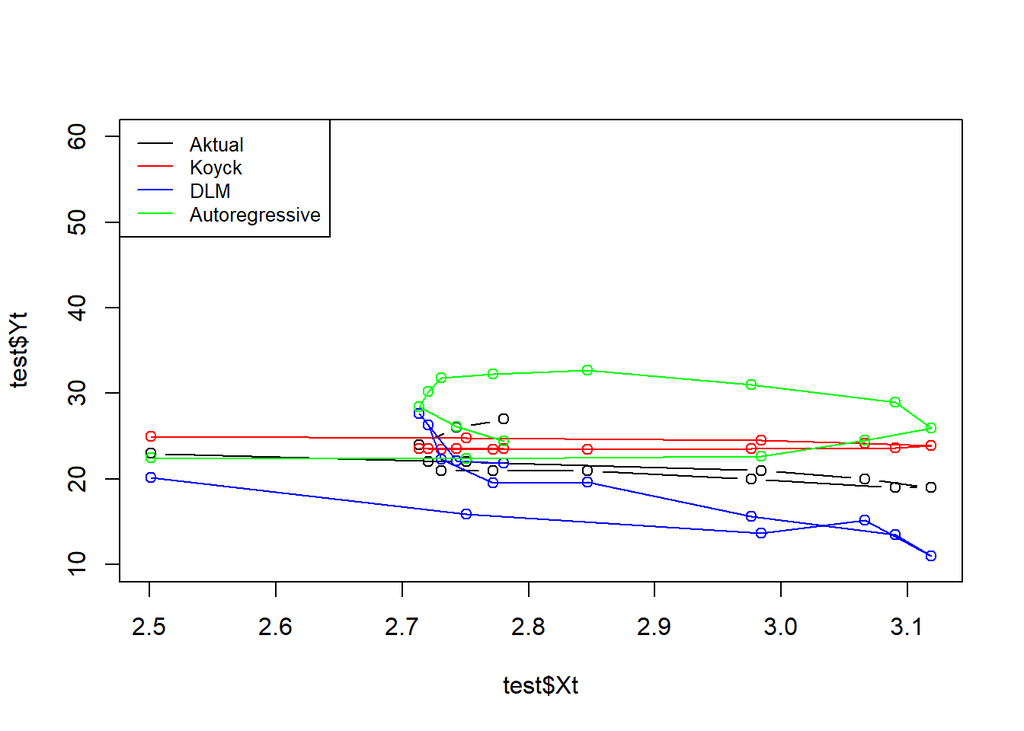

```r
par(mfrow=c(1,1))  # atur layout grafik tunggal

# plot data aktual
plot(test$Xt, test$Yt, type="b", col="black", ylim=c(10,60))

# tambahkan garis ramalan dari masing-masing model
points(test$Xt, fore.koyck$forecasts, col="red");   lines(test$Xt, fore.koyck$forecasts, col="red")
points(test$Xt, fore.dlm$forecasts, col="blue");    lines(test$Xt, fore.dlm$forecasts, col="blue")
points(test$Xt, fore.ardl$forecasts, col="green");  lines(test$Xt, fore.ardl$forecasts, col="green")

# legenda model
legend("topleft",
       c("Aktual", "Koyck","DLM", "Autoregressive"),
       lty=1, col=c("black","red","blue","green"), cex=0.8)
```

```r
length(test$Xt)
```

```
## [1] 14
```

```r
length(test$Yt)
```

```
## [1] 14
```

```r
length(fore.dlm$forecasts)
```

```
## [1] 14
```

# Uji Asumsi

## SSE

```r
deviance(model.dlm$model)
```

```
## [1] 0.01679438
```

## Autokorelasi

```r
dwtest(model.dlm$model)
```

```
##
##  Durbin-Watson test
##
## data:  model.dlm$model
## DW = 3.3726, p-value = 1
## alternative hypothesis: true autocorrelation is greater than 0
```

## Heterogenitas

```r
bptest(model.dlm$model)
```

```
##
##  studentized Breusch-Pagan test
##
## data:  model.dlm$model
## BP = 24.223, df = 28, p-value = 0.6697
```

## Kenormalan

```r
shapiro.test(residuals(model.dlm$model))
```

```
##
##  Shapiro-Wilk normality test
##
## data:  residuals(model.dlm$model)
## W = 0.95011, p-value = 0.1702
```

Berdasarkan uji asumsi tersebut, model DLM menyatakan bahwa semua asumsi sudah terpenuhi karena nilai p yang dihasilkan lebih besar dari 0.05 baik pada tidak adanya autokorelasi, ragam sisaan homogen, bahkan sisan menyebar normal.